# Practical Machine Learning

# April 2, 2017

Excercising is an important part for a fit and healthy living. Tracking the excercises Using different devices such as Jawbone Up, Nike FuelBand, and Fitbit can help people on seeing their progress and motivate them to continue on their activities. They can see how much they do it and how well they do it since optimal results can be achieved using the correct quantity and quality of exercises.

The goal of this project is to use data from accelerometers on the belt, forearm, arm, and dumbell of 6 participants. They were asked to peranFororm 5 different exercises correctly and incorrectly. The data for this project come from this source: http://groupware.les.inf.puc-rio.br/har

# Loading and Cleaning data

Using the given URL for the test and training data we will be loading the CSVs and remove data from the first 7 columns, 0 and missing values. The cleaned data will be represented by trainData and testData.

```r
library(caret)
library(rpart)
```

```r
library(rpart.plot)
library(RColorBrewer)
library(rattle)
library(randomForest)
trainUrl <- "http://d396qusza40orc.cloudfront.net/predmachlearn/pml-training.csv"
testUrl <- "http://d396qusza40orc.cloudfront.net/predmachlearn/pml-testing.csv"
traincsv <- read.csv(url(trainUrl), na.strings=c("NA","#DIV/0!",""))
testcsv <- read.csv(url(testUrl), na.strings=c("NA","#DIV/0!",""))
traincsv <- traincsv[, colSums(is.na(traincsv)) == 0]
testcsv <- testcsv[, colSums(is.na(testcsv)) == 0]
trainData <- traincsv[, -c(1:7)]
testData <- testcsv[, -c(1:7)]
```

# Data Splitting

We split the cleaned training set trainData into a training set (data_train, 80%) and a testing set (data_test 20%). Our predictions will come out from this two tests.

```r
sample_train <- sample(nrow(trainData), nrow(trainData)*0.8)
data_train <- trainData[sample_train, ]
data_test <- trainData[-sample_train, ]
```

# Predictions

## Predicting with trees

We will first predict the outcomes using trees.

```r
model_fit <- rpart(classe ~ ., data = data_train, method = "class")
predict_rpart <- predict(model_fit, data_test, type="class")
print(model_fit, digits = 4)
```

```
## n= 15697
##
## node), split, n, loss, yval, (yprob)
##       * denotes terminal node
##
##     1) root 15697 11220 A (0.29 0.19 0.18 0.16 0.18)
##       2) roll_belt< 130.5 14368  9900 A (0.31 0.21 0.19 0.18 0.11)
##         4) pitch_forearm< -33.95 1275     7 A (0.99 0.0055 0 0 0) *
##         5) pitch_forearm>=-33.95 13093  9893 A (0.24 0.23 0.21 0.2 0.12)
##          10) magnet_dumbbell_y< 439.5 11114  7983 A (0.28 0.18 0.24 0.19 0.11)
##            20) roll_forearm< 123.5 6901  4091 A (0.41 0.18 0.18 0.17 0.06)
##              40) magnet_dumbbell_z< -27.5 2310   760 A (0.67 0.21 0.013 0.077 0.027) *
##              41) magnet_dumbbell_z>=-27.5 4591  3331 A (0.27 0.17 0.27 0.21 0.076)
##                82) accel_dumbbell_y>=-40.5 4038  2784 A (0.31 0.18 0.19 0.24 0.081)
##                 164) yaw_belt>=168.5 583    81 A (0.86 0.074 0.0017 0.06 0.0034) *
##                 165) yaw_belt< 168.5 3455  2527 D (0.22 0.2 0.22 0.27 0.094)
##                   330) pitch_belt< -42.85 408    70 B (0.015 0.83 0.11 0.029 0.017) *
##                   331) pitch_belt>=-42.85 3047  2131 D (0.24 0.12 0.23 0.3 0.1)
##                     662) roll_belt>=125.5 720   301 C (0.39 0.017 0.58 0.0097 0.0042)
##                      1324) magnet_belt_z< -323.5 242     6 A (0.98 0 0.012 0 0.012) *
##                      1325) magnet_belt_z>=-323.5 478    62 C (0.09 0.025 0.87 0.015 0) *
##                     663) roll_belt< 125.5 2327  1418 D (0.2 0.15 0.12 0.39 0.14)
##                      1326) pitch_belt>=1.31 1494  1135 A (0.24 0.21 0.13 0.22 0.19)
##                        2652) yaw_forearm>=-95.65 1189   830 A (0.3 0.26 0.12 0.094 0.22)
##                          5304) accel_dumbbell_z< 21.5 660   330 A (0.5 0.18 0.22 0.079 0.024)
##                           10608) magnet_forearm_z>=-166 453   127 A (0.72 0.13 0.022 0.1 0.024) *
##                           10609) magnet_forearm_z< -166 207    72 C (0.019 0.28 0.65 0.024 0.024) *
##                          5305) accel_dumbbell_z>=21.5 529   278 E (0.055 0.35 0.0038 0.11 0.47)
##                           10610) roll_dumbbell< 36.85 186    39 B (0.048 0.79 0.011 0.032 0.12) *
##                           10611) roll_dumbbell>=36.85 343   114 E (0.058 0.12 0 0.16 0.67) *
##                        2653) yaw_forearm< -95.65 305    84 D (0 0.056 0.16 0.72 0.056) *
##                      1327) pitch_belt< 1.31 833   257 D (0.13 0.03 0.11 0.69 0.038) *
##                83) accel_dumbbell_y< -40.5 553    68 C (0.011 0.043 0.88 0.027 0.042) *
##            21) roll_forearm>=123.5 4213  2819 C (0.076 0.18 0.33 0.23 0.18)
##              42) magnet_dumbbell_y< 290.5 2458  1256 C (0.091 0.13 0.49 0.15 0.14)
##                84) magnet_forearm_z< -251 191    42 A (0.78 0.063 0 0.058 0.099) *
##                85) magnet_forearm_z>=-251 2267  1065 C (0.033 0.14 0.53 0.15 0.14)
##                 170) pitch_belt>=26.15 152    33 B (0.092 0.78 0.039 0 0.086) *
##                 171) pitch_belt< 26.15 2115   919 C (0.028 0.093 0.57 0.16 0.15) *
##              43) magnet_dumbbell_y>=290.5 1755  1145 D (0.056 0.25 0.11 0.35 0.24)
##                86) accel_forearm_x>=-102.5 1135   761 E (0.05 0.32 0.15 0.15 0.33)
##                 172) magnet_arm_y>=188.5 462   204 B (0.015 0.56 0.21 0.1 0.11) *
##                 173) magnet_arm_y< 188.5 673   351 E (0.074 0.15 0.1 0.19 0.48) *
##                87) accel_forearm_x< -102.5 620   184 D (0.066 0.12 0.039 0.7 0.069) *
##          11) magnet_dumbbell_y>=439.5 1979   979 B (0.035 0.51 0.043 0.23 0.19)
##            22) total_accel_dumbbell>=5.5 1410   501 B (0.049 0.64 0.06 0.021 0.23)
##              44) roll_belt>=-0.58 1195   286 B (0.058 0.76 0.07 0.025 0.086) *
##              45) roll_belt< -0.58 215     0 E (0 0 0 0 1) *
##            23) total_accel_dumbbell< 5.5 569   148 D (0 0.16 0.0035 0.74 0.097) *
##       3) roll_belt>=130.5 1329     9 E (0.0068 0 0 0 0.99) *
```

We can see the prediction tree plot below:

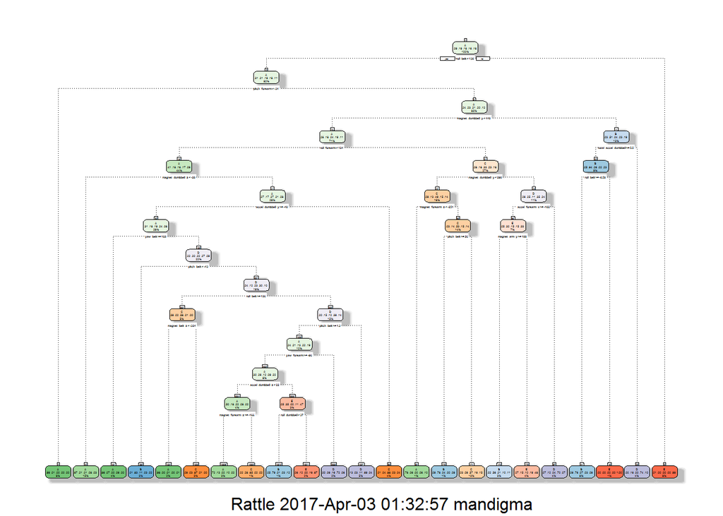

```r
fancyRpartPlot(model_fit)
```

```r
(conf_rpart <- confusionMatrix(data_test$classe, predict_rpart))
```

```
## Confusion Matrix and Statistics
##
##           Reference
## Prediction   A   B   C   D   E
##          A 994  24  23  35  27
##          B 168 448  69  56  32
##          C  12  64 536  39  21
##          D  79  23 100 406  33
##          E  31  54  85  49 517
##
## Overall Statistics
##
##                Accuracy : 0.7391
##                  95% CI : (0.7251, 0.7528)
##     No Information Rate : 0.3271
##     P-Value [Acc > NIR] : < 2.2e-16
##
##                   Kappa : 0.6687
##  Mcnemar's Test P-Value : < 2.2e-16
##
## Statistics by Class:
##
##                      Class: A Class: B Class: C Class: D Class: E
## Sensitivity            0.7741   0.7308   0.6593   0.6940   0.8206
## Specificity            0.9587   0.9019   0.9563   0.9296   0.9335
## Pos Pred Value         0.9012   0.5796   0.7976   0.6334   0.7024
## Neg Pred Value         0.8972   0.9477   0.9148   0.9455   0.9646
## Prevalence             0.3271   0.1562   0.2071   0.1490   0.1605
## Detection Rate         0.2532   0.1141   0.1366   0.1034   0.1317
## Detection Prevalence   0.2810   0.1969   0.1712   0.1633   0.1875
## Balanced Accuracy      0.8664   0.8164   0.8078   0.8118   0.8771
```

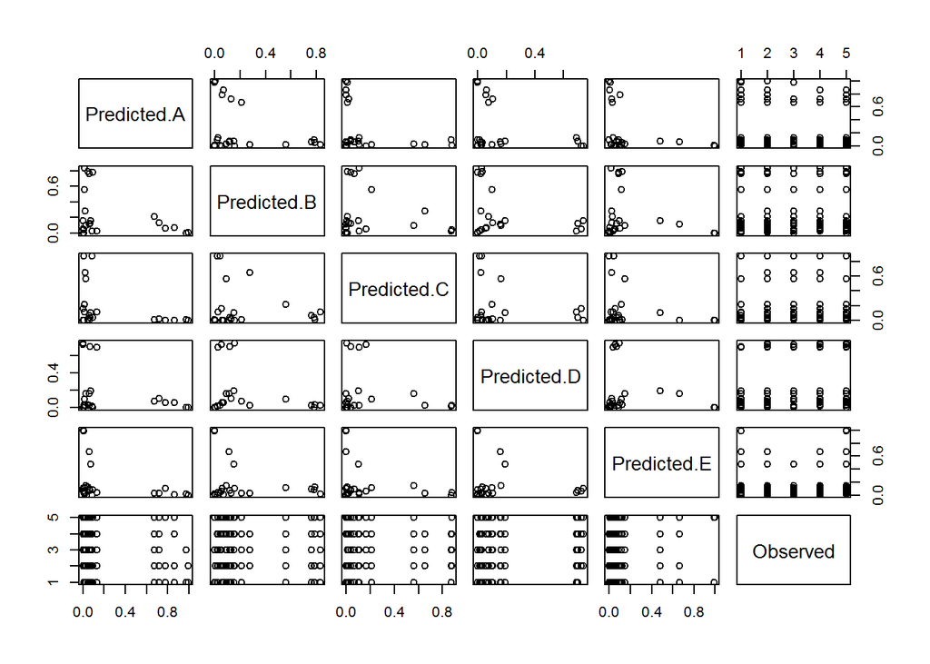

```r
plot(data.frame("Predicted"=predict(model_fit, data_test), "Observed"=data_test$classe))
```

## Random Forest

We will next try using the Random FOrest method if we can have a better outcome.

```r
fit_ranFor <- randomForest(classe ~. , data=data_train)
print(fit_ranFor, digits = 4)
```

```
##
## Call:
##  randomForest(formula = classe ~ ., data = data_train)
##                Type of random forest: classification
##                      Number of trees: 500
## No. of variables tried at each split: 7
##
##         OOB estimate of  error rate: 0.39%
## Confusion matrix:
##      A    B    C    D    E  class.error
## A 4475    2    0    0    0 0.0004467277
## B   14 3004    6    0    0 0.0066137566
## C    0    9 2739    2    0 0.0040000000
## D    0    0   18 2556    1 0.0073786408
## E    0    0    2    8 2861 0.0034831069
```

```r
predict_ranFor <- predict(fit_ranFor, data_test)
(conf_ranFor <- confusionMatrix(data_test$classe, predict_ranFor))
```

```
## Confusion Matrix and Statistics
##
##           Reference
## Prediction    A    B    C    D    E
##          A 1102    1    0    0    0
##          B    2  769    2    0    0
##          C    0    3  668    1    0
##          D    0    0    9  631    1
##          E    0    0    1    2  733
##
## Overall Statistics
##
##                Accuracy : 0.9944
##                  95% CI : (0.9915, 0.9965)
##     No Information Rate : 0.2813
##     P-Value [Acc > NIR] : < 2.2e-16
##
##                   Kappa : 0.9929
##  Mcnemar's Test P-Value : NA
##
## Statistics by Class:
##
##                      Class: A Class: B Class: C Class: D Class: E
## Sensitivity            0.9982   0.9948   0.9824   0.9953   0.9986
## Specificity            0.9996   0.9987   0.9988   0.9970   0.9991
## Pos Pred Value         0.9991   0.9948   0.9940   0.9844   0.9959
## Neg Pred Value         0.9993   0.9987   0.9963   0.9991   0.9997
## Prevalence             0.2813   0.1969   0.1732   0.1615   0.1870
## Detection Rate         0.2808   0.1959   0.1702   0.1608   0.1868
## Detection Prevalence   0.2810   0.1969   0.1712   0.1633   0.1875
## Balanced Accuracy      0.9989   0.9968   0.9906   0.9961   0.9988
```

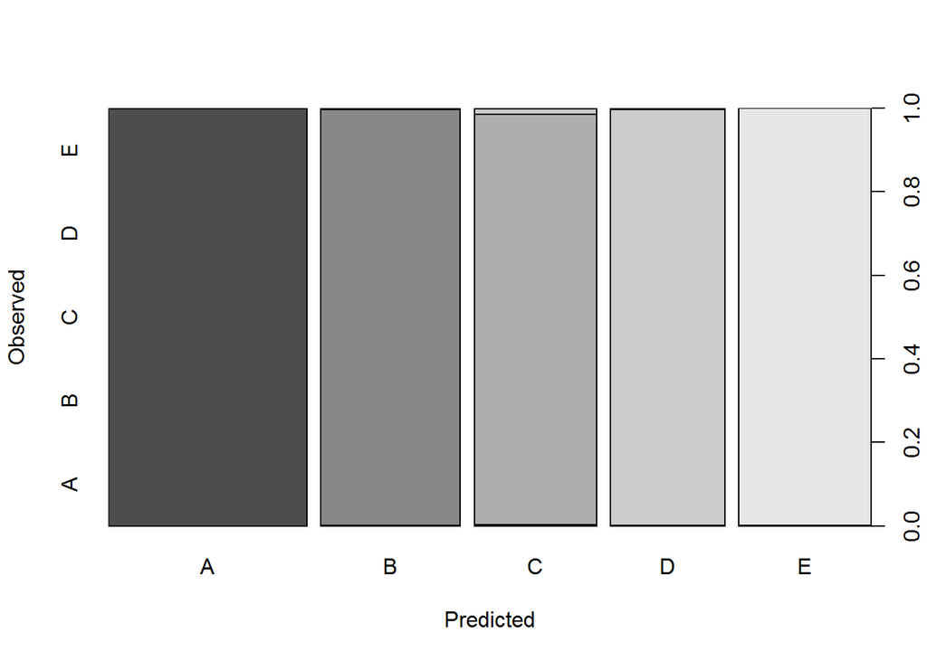

```r
plot(data.frame("Predicted"=predict(fit_ranFor, data_test), "Observed"=data_test$classe))
```

# Prediction on the testing data set

We will now predict the testing data for 1 to 20. These will be the answers to the quiz.

```r
prediction_final <- predict(fit_ranFor, testData, type = "class")
data.frame( problem_id=testcsv$problem_id, predicted=prediction_final)
```

```
##    problem_id predicted
## 1           1         B
## 2           2         A
## 3           3         B
## 4           4         A
## 5           5         A
## 6           6         E
## 7           7         D
## 8           8         B
## 9           9         A
## 10         10         A
## 11         11         B
## 12         12         C
## 13         13         B
## 14         14         A
## 15         15         E
## 16         16         E
## 17         17         A
## 18         18         B
## 19         19         B
## 20         20         B
```